# Lab 3: Visualizing oceanographic sections

This lab focuses on visualizing oceanographic sections. The tools you are introduced to here can be used to graph and analyze data in your labs, your independent research projects and the cruise data gathered throughout the semester. Be sure to save any scripts that you develop so you can continue to use them.

# 1. Importing and wrangling data

This week, we are going to start with the data from the csv files we created last week. However, before we can plot the oceanographic sections, we need to wrangle the data into an easier form to work with. A lot of your time coding can be spent wrangling data, but it is definitely worth spending the time to get your data into a format that is easy to use, manipulate, plot and analyze.

Let’s start by importing the data as before.

```r
# read in the whole csv file
DATA <- read.csv('Colby_cruise_data_2012-2017.csv', header = TRUE)
```

## 1.1 Coding technique: for-loops

When you want to repeat the same bit of code multiple times, a for-loop can be your friend. For example, if you would like to plot a section for each cruise, rather than type out the code for each cruise individually, we can just write it once and iterate or *loop* over the code.

Let’s start with a simple example:

#### Example: print the statement “hello” four times

```r
for (ii in 1:4) {
  print("hello")
}
```

```
[1] "hello"
[1] "hello"
[1] "hello"
[1] "hello"
```

#### Example: print the statement “hello” four times, including the number at the start of the statement e.g. “1 hello”

```r
for (ii in 1:4) {
  print(paste(ii,"hello"))
}
```

```
[1] "1 hello"
[1] "2 hello"
[1] "3 hello"
[1] "4 hello"
```

## 1.2 Wrangling data

For reasons which will become apparent later, we are going to group our data by cruise, then by station. To do this we are going to take the following steps:

1. loop through each cruise (using the dates to identify different cruises)
2. extract the data for the required cruise from the main `DATA` data frame
3. create a unique cruise name for the required cruise of the form: colbyYYYYMMDD, where YYYYMMDD is the date in year, month, day
4. loop through each station (for a given cruise)
5. extract the data for the required station from the required cruise
6. add the station data to a list, labeling it by the station number
7. add the station list data to a master list, labeling it with the unique cruise id.

```r
#making a list of the dates of each cruise
dates <- unique(DATA[['Date']])
#creating an empty list which we will fill with more lists in a for-loop
cruiseList <- list()
#loop to extract each cruise from the main DATA list and to group the individual cruise lists into one master list: cruiseList
for (dd in dates){
  #extracting a specific cruise into a list from the main DATA list
  cruiseData <- DATA[DATA[['Date']] == dd,]

  #making a unique cruise id
  id <- paste("colby",dd,sep="")

  #making a unique station id
  stations <- unique(cruiseData$Station)
  #creating an empty list to be filled by each station on the next for-loop
  stationList <- list()

  #loop to extract each station from the cruiseData dataframe and to group the individual stations into one list for a given cruise= stationList
  for (ss in stations){
    #extracting a specific station from the cruiseData dataframe
    stationData <- cruiseData[cruiseData$Station == ss,]

    #making a station id
    stationID <- paste('station',ss,sep = '')

    #adding the stationData to the station list, naming it with the station id
    stationList[[stationID]] <- stationData
  }

  #adding the staton list to the master cruiseList, naming it with the unique id
  cruiseList[[id]] <- stationList
}
```

# 2. Plotting oceanographic section

In this section, we’ll plot oceanographic sections for past Colby Semester cruises. To do this, we’ll make use of the fields package, which provides tools for analyzing and visualizing spatial data.

```r
library("fields")
```

#### Example: plot a temperature section for the colby20170912 cruise

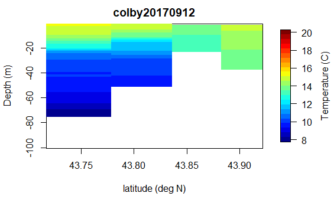

```r
cruiseData <- cruiseList$colby20170912
stationLat <- c(43+54.130/60, 43+51.8/60, 43+48.56/60, 43+44.87/60)
TEM <- matrix(NA,nrow = 100, ncol = 4)
stations = names(cruiseData)
for (st in stations){
  for (j in 1:100){
    stationData <- cruiseData[[st]]

    stationNum <- as.numeric(substr(st,nchar(st),nchar(st)))

    TEM[j,stationNum] <- mean(stationData[ceiling(stationData$Depth)==j,'Temperature'])
  }
}
image.plot(x=stationLat[4:1],y=-100:-1,t(TEM[100:1,4:1]),
           zlim=c(8,20),
           col=tim.colors(24),
           xlab='latitude (deg N)',
           ylab='Depth (m)',
           main='colby20170912',
           legend.lab='Temperature (C)',
legend.line=2.5)
```

#### Example: How do we change the color scheme?

1. We can use one of the R color palettes e.g. `heat.colors`, `terrain.colors`, `topo.colors` as the `col` argument in place of the `tim.colors` argument.
2. We can use one of the Color Brewer palettes. Color Brewer was a project which created a lot of different color palettes for thematic maps. There are different types of color palettes depending on your needs (e.g. sequential color scale, diverging color scale, quantative scales). It has a cool web-interface (http://colorbrewer2.org/#) where you can play around with the palettes. What is good about Color Brewer is the sequential color palettes (the type we used in our above section plot) are made from at most 3 colors, and are altered by changing the hue. This makes the maps colorblind-friendly and prevents artificial sharp edges between color changes. R has a package for the Color Brewer palettes. Check out the help to see a list of the sequential palette names you can use.

```r
library("RColorBrewer")
```

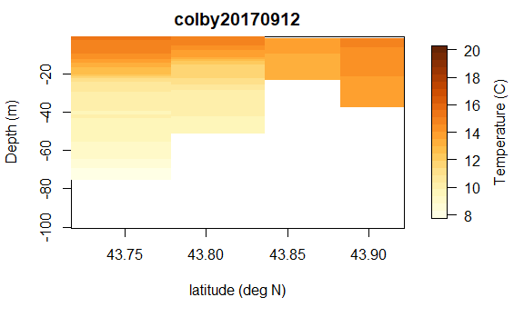

```r
colpal <- colorRampPalette(brewer.pal(9,'YlOrBr'))   # make colors
image.plot(x=stationLat[4:1],y=-100:-1,t(TEM[100:1,4:1]),
           zlim=c(8,20),
           col=colpal(24),
           xlab='latitude (deg N)',
           ylab='Depth (m)',
           main='colby20170912',
           legend.lab='Temperature (C)',
legend.line=2.5)
```

#### Example: Plot a temperature section for all the cruises

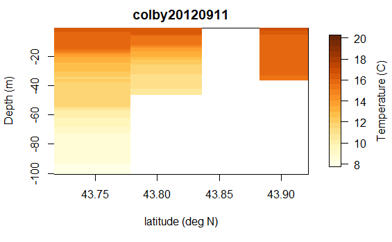

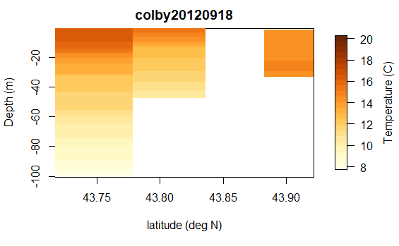

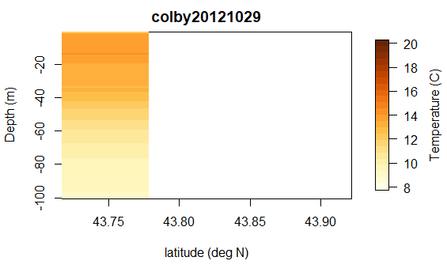

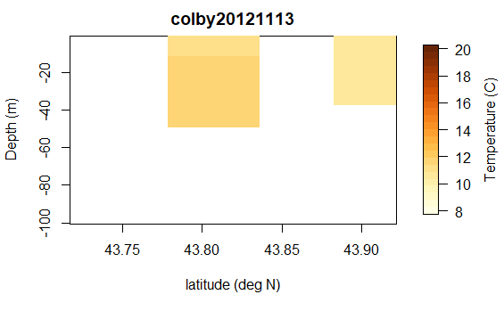

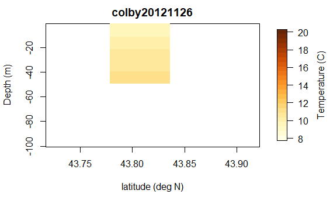

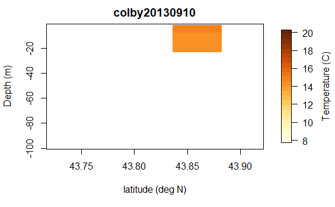

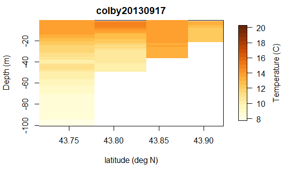

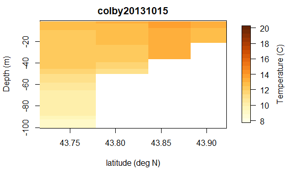

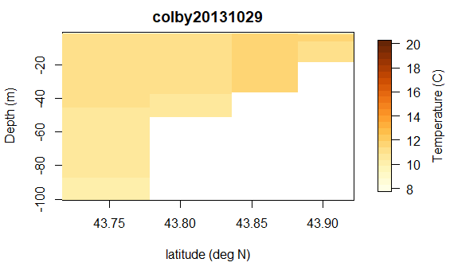

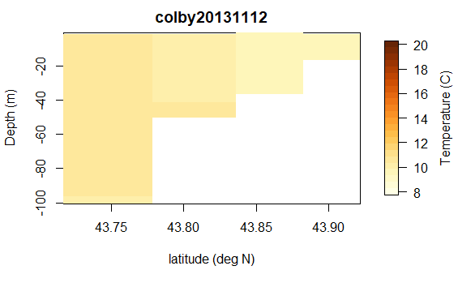

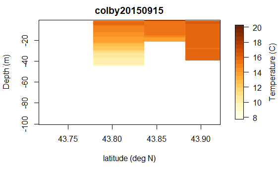

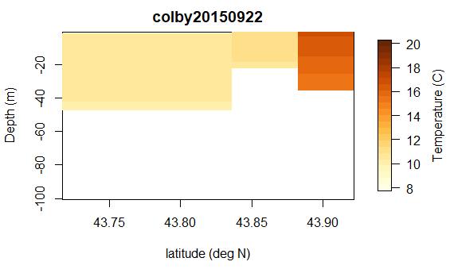

[14 more figures not shown]

```r
for (cruise in names(cruiseList)) {
  cruiseData <- cruiseList[[cruise]]

  stationLat <- c(43+54.130/60, 43+51.8/60, 43+48.56/60, 43+44.87/60)

  TEM <- matrix(NA,nrow = 100, ncol = 4)

  stations = names(cruiseData)

  for (st in stations){
    for (j in 1:100){
      stationData <- cruiseData[[st]]

      stationNum <- as.numeric(substr(st,nchar(st),nchar(st)))

      TEM[j,stationNum] <- mean(stationData[ceiling(stationData$Depth)==j,'Temperature'])
    }
  }

  image.plot(x=stationLat[4:1],y=-100:-1,t(TEM[100:1,4:1]),
             zlim=c(8,20),
             col=colpal(24),
             xlab='latitude (deg N)',
             ylab='Depth (m)',
             main=cruise,
             legend.lab='Temperature (C)',
  legend.line=2.5)
}
```

# 3. Assignment (in lab)

1. Try altering the color palette. Remember to find a list of the Color Brewer palettes, check the RColorBrewer help. For this type of image, use a sequential color palette.
2. Plot an oceanographic section for different variables. Remember to change the limits of the color scale by adjusting the `zlim` argument to `image.plot`.